# Projet final, Séries temporelles 2022

Hamady Cissé.R

05/04/2022

Voici la listes des library utilisé afin d’analyse ma serie au mieux :

```r
library(forecast)
```

```r
library(ggplot2)
library("GGally")
library(timeSeries)
```

**Premiere analyse**

Dans notre premiere analyse nous allons importer les données afin de voir à quoi cette serie ressemble:

```r
SerieVector<- scan('C:/Users/hamad/Downloads/serie_06 (1).dat')
```

L’importation des données de cette serie vont nous permettre de la transformer en serie temporelle :

```r
SerieTemp<-ts(SerieVector,frequency = 12,start = c(2002,1))
```

Regardons maintenant à quoi ressemble notre serie temporelle :

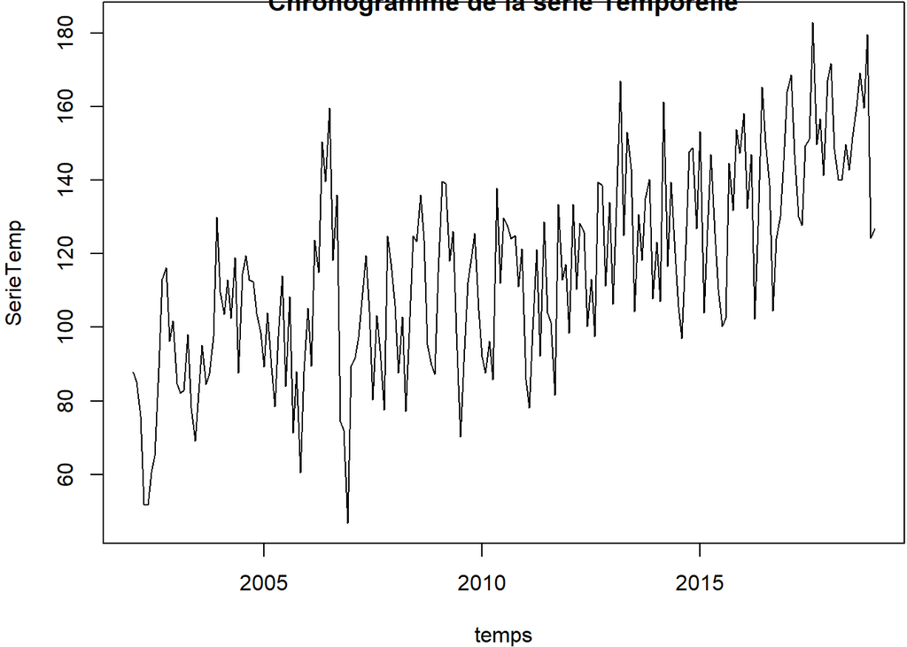

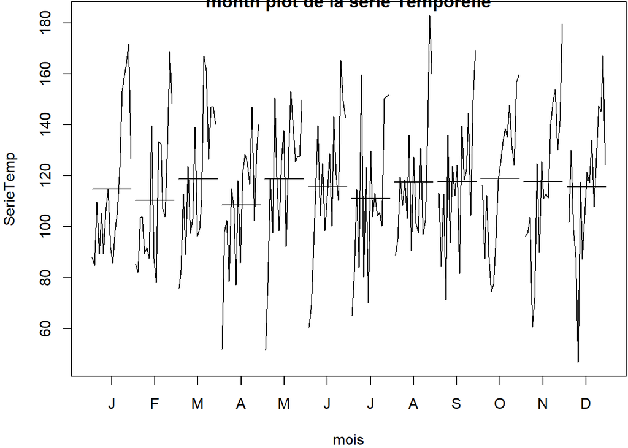

```r
par(mar=c(4,4,.1,.1))
plot.ts(SerieTemp,main='Chronogramme de la série Temporelle',xlab='temps')
monthplot(SerieTemp,main='month plot de la série Temporelle',xlab='mois')
```

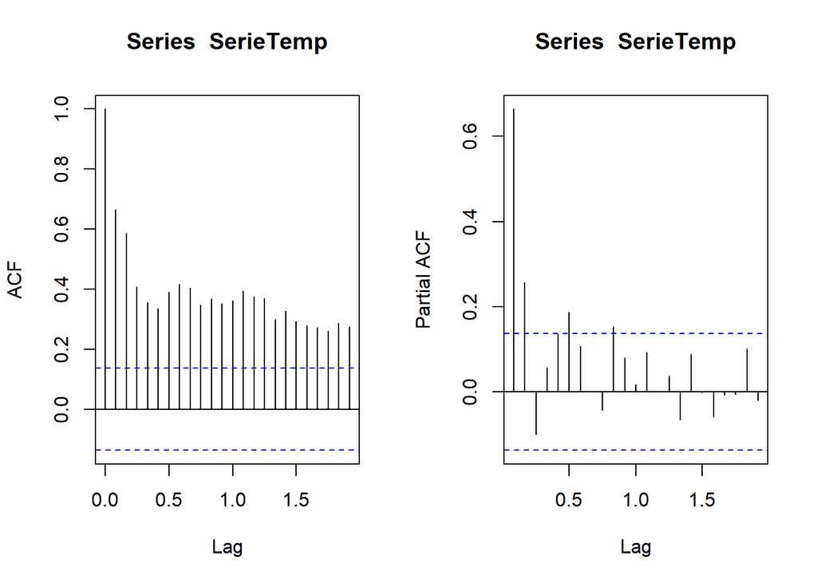

```r
par(mfrow=c(1,2))
acf(SerieTemp)
pacf(SerieTemp)
```

L’autocorrelogramme(acf) ainsi que l’autocorrelogramme partiel(pacf) de cette serie ne semble clairement pas stationnaire il y a de toute evidence une tendance.De plus,on remarque une correlation positive sur l’acf avec aucune valeur qui s’annule .

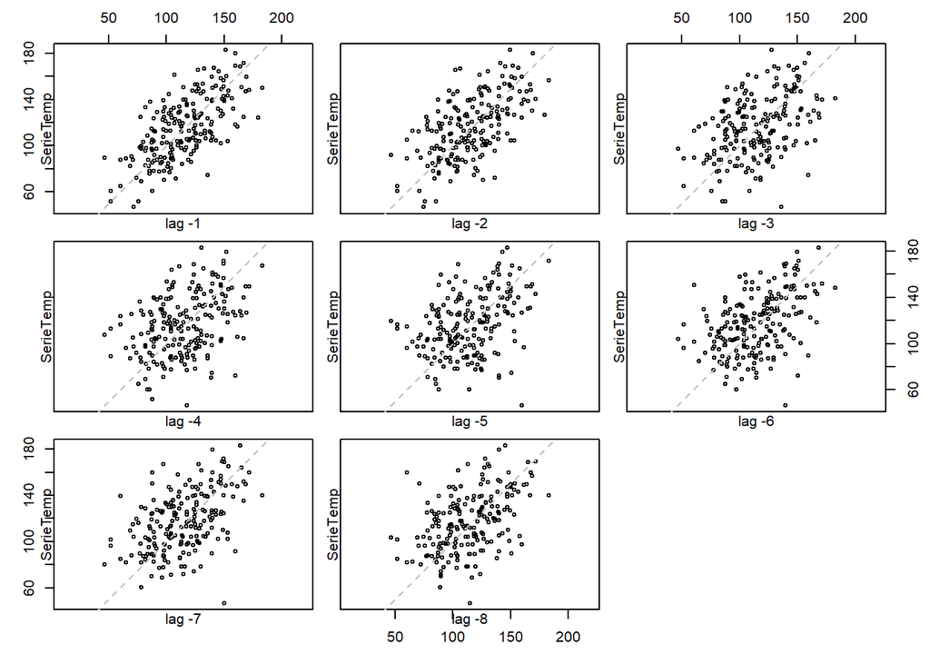

```r
lag.plot(SerieTemp,set.lags = -(1:8))
```

Le lagplot vient confirmer le faite qu’il n’y a pas de decroissance exponentielle mais plutot une correlation positive.

Enlevons la tendance ainsi que la saisonnalité sur cette serie qui semble non stationnaire.

```r
 q=12/2 #periode=12
 l=length(SerieVector)
 SerieTendance=rep(NA,l)
for(t in (1+q):(l-q)){ #cas longeur periode pair
 SerieTendance[t]= 1/12 * (0.5*SerieVector[t-q]+sum(SerieVector[(t-q+1):(t+q-1)])+0.5*SerieVector[t+q]) }
 SerieTendance=ts(SerieTendance,start=c(2002,1),frequency=12) #necessaire pour pouvoir comparer graphiques
 Xsanstendance=SerieTemp-SerieTendance #s´ecrie sans tendance
 Xsanstendance
```

```
##               Jan          Feb          Mar          Apr          May
## 2002           NA           NA           NA           NA           NA
## 2003  -5.66028253  -9.34617977  -7.68335507  10.06662262  -8.74672313
## 2004   7.21942236  -1.05377820   6.02510677  -6.69318635   8.62771163
## 2005 -12.22744045   4.15761705  -8.61944231 -16.49762970   5.50594550
## 2006   0.20905630 -19.28856436  12.02031071   0.94419458  36.64452353
## 2007  -8.55430614  -2.39589942   5.52377579  17.25673473  27.06841286
## 2008   4.61800591 -16.85822338  -4.18142866 -31.93302895  -9.98638453
## 2009   1.15043786  29.98464157  31.81918037  10.31391376  15.81753695
## 2010 -13.29022563 -21.59609318 -15.05952470 -26.24635016  26.17952328
## 2011 -25.17055355 -30.68418195  -6.51398709  16.71611903 -12.70824393
## 2012 -14.20185627  20.51069736  -4.71735783  10.64019960   8.10640561
## 2013 -23.37650835   1.85580121  35.74158505  -5.23716496  21.79997419
## 2014  -2.23098390 -16.95665291  38.56175699  -6.90551483  15.14933721
## 2015  27.13022678 -22.07327383  -0.78732946  19.58485777  -1.40562567
```

[output cut: 42 more lines]

```r
 W=rep(NA,12)
 p=floor(l/12)
 for(k in 1:12) W[k]=mean(Xsanstendance[((1:p)-1)*12+k],na.rm=TRUE)
 Sh=W-mean(W)
 Sh=c(rep(Sh,p))
 Sh=ts(Sh,start=c(2002,1),frequency=12)
 XsansSaisonalite = SerieTemp-Sh
 XsansSaisonalite
```

```
##            Jan       Feb       Mar       Apr       May       Jun       Jul
## 2002  87.97659  89.69540  71.18435  56.77874  45.96902  58.63749  69.50155
## 2003  84.90379  86.47115  77.99865 102.98264  72.36659  67.17004  86.63506
## 2004 109.73800 108.10304 108.17260 107.30766 113.27693  85.79095 119.06182
## 2005  89.50049 108.42983  84.24489  83.23629  91.76086 112.10802  88.52598
## 2006 105.47472  93.81758 119.03253 119.72375 144.68823 137.81982 164.24170
## 2007  89.70305  96.20527  92.53179 112.26203 113.75801 102.38695  84.77241
## 2008 106.09107  92.05704  98.14501  82.01029  92.58538 123.04543 127.88032
## 2009 115.09023 144.08863 134.33682 122.94481 120.25243  96.56842  74.68135
## 2010  92.12460  92.11810  91.49191  90.70354 132.14174 110.10819 134.25640
## 2011  85.96315  82.56454  94.66963 126.10749  86.45509 126.92943 108.42726
## 2012  98.61499 137.82738 105.64210 133.25310 120.21850  98.35921 117.57443
## 2013 106.51955 137.04238 162.21388 129.83204 147.27489 141.25346 108.82337
## 2014 123.36118 111.55995 156.64449 121.51278 133.80480 118.50597 110.09351
## 2015 153.34858 108.43753 121.68026 151.93858 119.83411 108.54857 104.81277
```

[output cut: 21 more lines]

```r
Residu=SerieTemp-SerieTendance-Sh
Residu
```

```
##              Jan         Feb         Mar         Apr         May         Jun
## 2002          NA          NA          NA          NA          NA          NA
## 2003  -5.4853597  -4.8935979 -12.4365676  14.9418696 -14.5240481 -20.9440694
## 2004   7.3943452   3.3988037   1.2718942  -1.8179394   2.8503867 -23.5960396
## 2005 -12.0525176   8.6101989 -13.3726549 -11.6223827  -0.2713795  22.3314110
## 2006   0.3839791 -14.8359825   7.2670982   5.8194415  30.8671986  25.2337231
## 2007  -8.3793833   2.0566824   0.7705632  22.1319817  21.2910879   4.7627964
## 2008   4.7929288 -12.4056415  -8.9346412 -27.0577820 -15.7637095  17.4156709
## 2009   1.3253607  34.4372234  27.0659678  15.1891607  10.0402120 -15.8519027
## 2010 -13.1153028 -17.1435113 -19.8127373 -21.3711032  20.4021983  -1.7282844
## 2011 -24.9956307 -26.2316001 -11.2671996  21.5913660 -18.4855689  22.0936118
## 2012 -14.0269334  24.9632792  -9.4705704  15.5154466   2.3290806 -20.1696573
## 2013 -23.2015855   6.3083831  30.9883725  -0.3619180  16.0226492   9.8954552
## 2014  -2.0560611 -12.5040710  33.8085444  -2.0302679   9.3720122  -7.0892325
## 2015  27.3051496 -17.6206920  -5.5405420  24.4601047  -7.1829506 -19.5284895
```

[output cut: 21 more lines]

La tendance de la Serie temporelle correspond bien à la tendance de la fonction decompose.

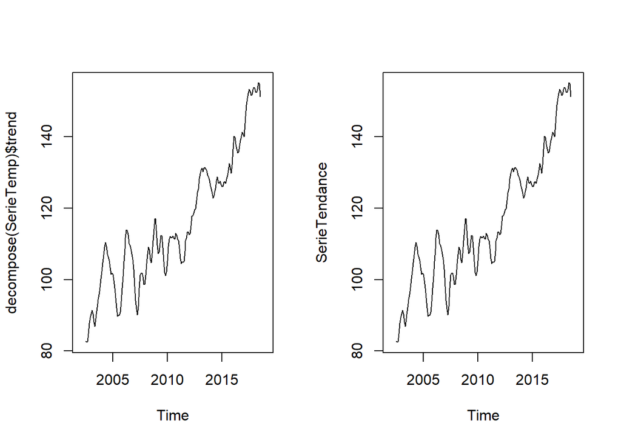

```r
par(mfrow=c(1,2))
plot(decompose(SerieTemp)$trend)
plot(SerieTendance)
```

La saisonnalité de la Serie temporelle corespond bien a la saisonnalité de la fonction decompose.

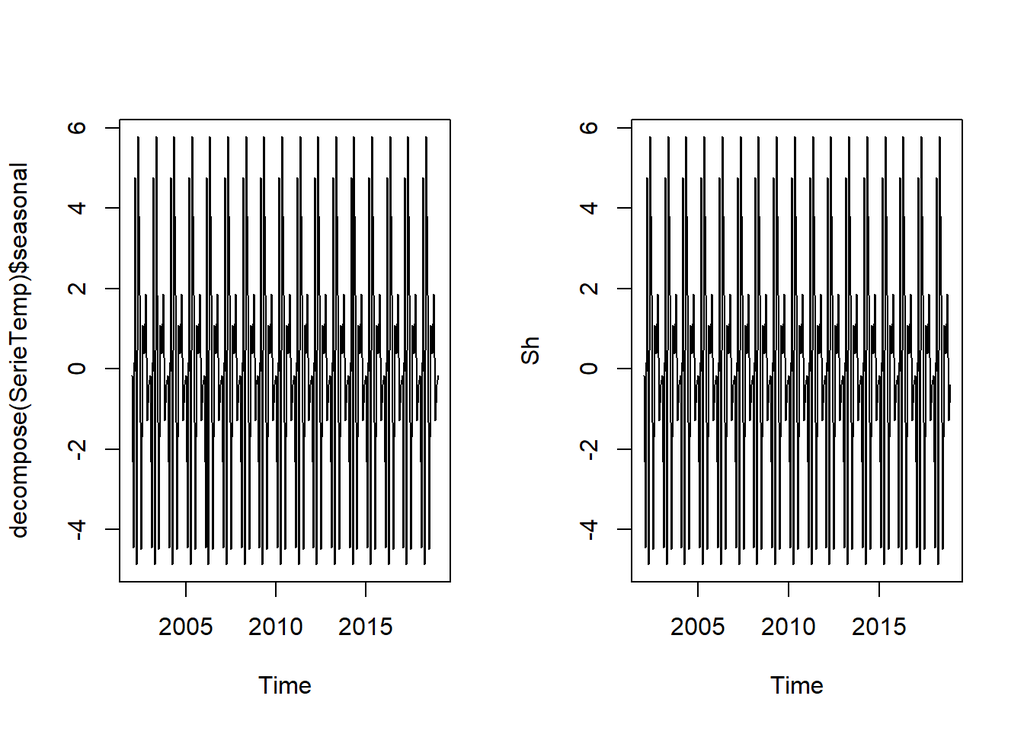

```r
par(mfrow=c(1,2))
plot(decompose(SerieTemp)$seasonal)
plot(Sh)
```

Le residu de la Serie temporelle correspond egalement au residu la fonction decompse.

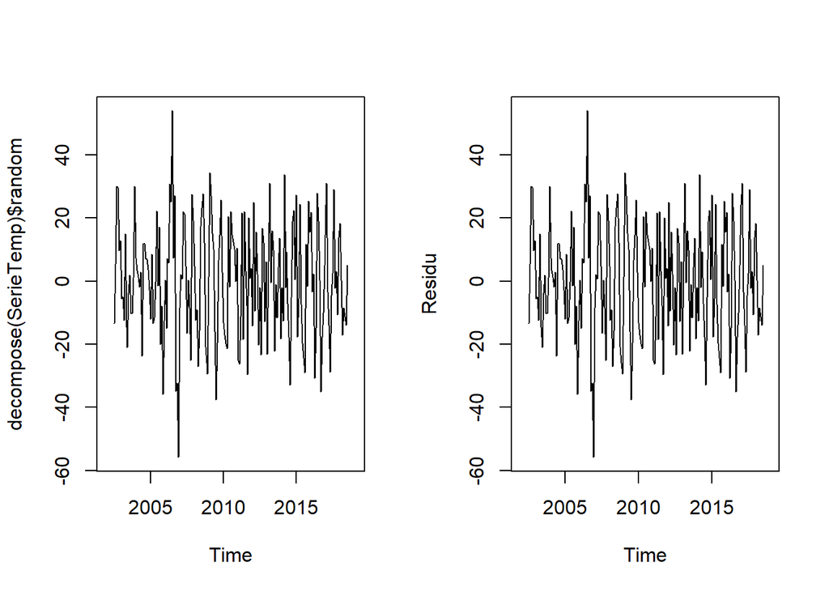

```r
par(mfrow=c(1,2))
plot(decompose(SerieTemp)$random)
plot(Residu)
```

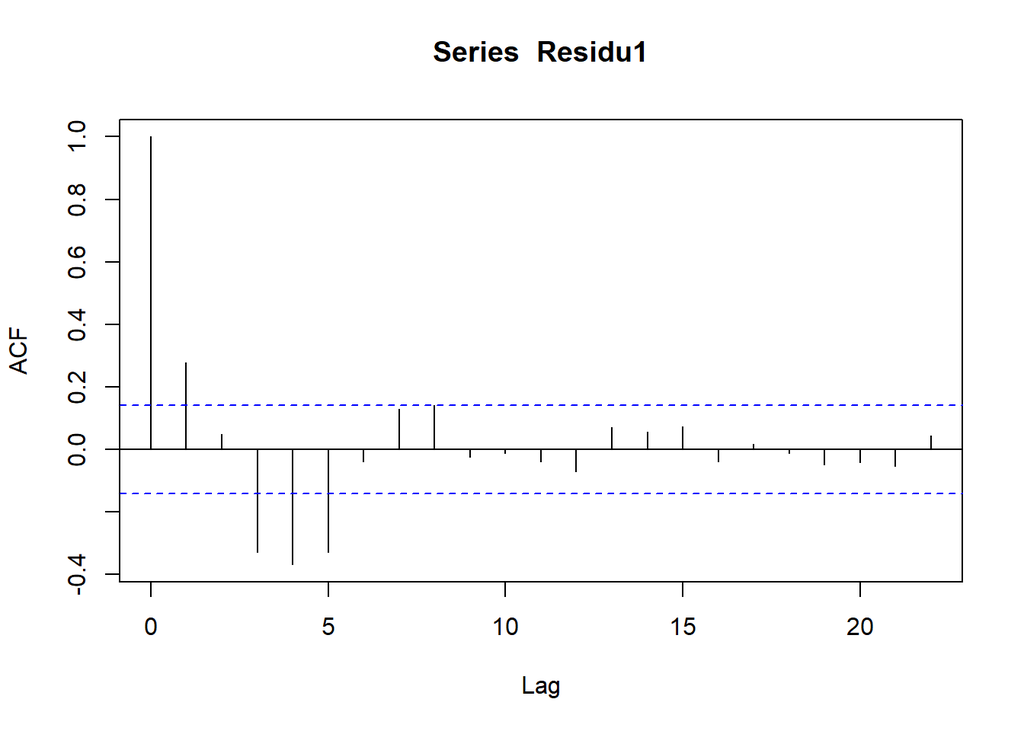

```r
Residu1=Residu[-which(is.na(Residu))]
acf(Residu1)
```

Le modele ma(5) est le modele le plus approprier etant donné que l’acf s’annule en ma(6).Le modèle ma(1) aurait pu etre choisi mais ne possede pas assez de valeur pour l’efficacité de notre etude.

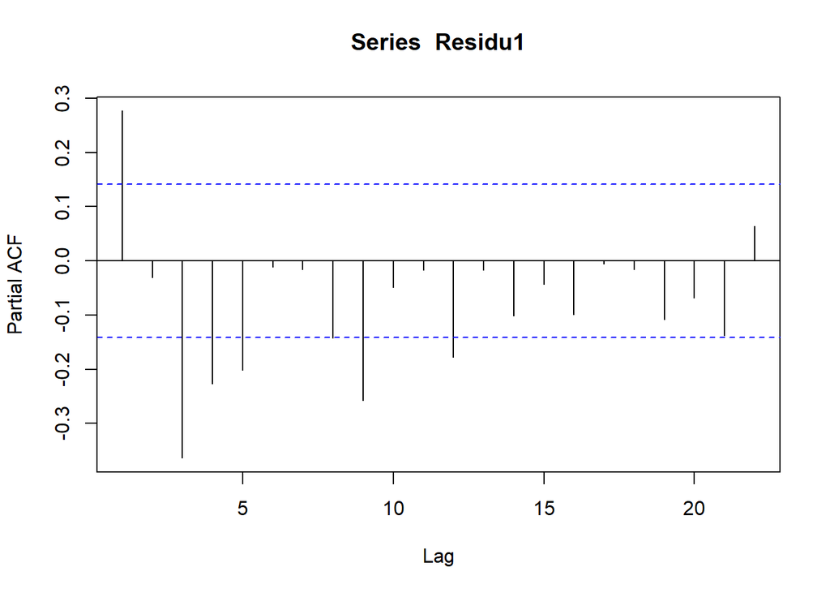

```r
pacf(Residu1)
```

```r
Residudebut=window(Residu,start=c(2002,7),end=c(2018,3),frequency=12)
Residufin=window(Residu,start=c(2018,4), end = c(2018, 7),frequency =12)
```

```r
mod1=arima(Residudebut,order=c(5,0,5))
confint(mod1)
```

```
##                  2.5 %       97.5 %
## ar1        1.238147647  2.017256883
## ar2       -1.608734046  0.034856827
## ar3       -1.512693810  0.167941052
## ar4        0.514099001  1.615797903
## ar5       -0.702230933 -0.230808524
## ma1       -2.204765238 -1.448223402
## ma2        0.004672734  1.816839928
## ma3       -0.676321696  1.329249961
## ma4       -1.844569584 -0.237279323
## ma5        0.258272610  1.002534233
## intercept -0.027260145  0.001362268
```

Le modele ar(5) et ma(5) ne sont pas significatif car 0 est compris dans chaqu’un des deux modeles.Nous allons donc essayer de trouver deux autres modeles significatif à comparer pour la suite de l’etude .

```r
mod1=arima(Residudebut,order=c(2,0,2))
#acf(mod1$residuals)
confint(mod1)
```

```
##                 2.5 %      97.5 %
## ar1        1.29445511  1.62748683
## ar2       -0.88350096 -0.63880386
## ma1       -1.77005893 -1.25809912
## ma2        0.25933522  0.76883148
## intercept -0.06141107  0.06202906
```

```r
mod2=arima(Residudebut,order=c(2,0,3))
confint(mod2)
```

```
##                 2.5 %      97.5 %
## ar1        1.07962838  1.43968376
## ar2       -0.84963845 -0.56648592
## ma1       -1.52143675 -1.11715351
## ma2        0.36771751  0.92843412
## ma3       -0.54549221 -0.11206818
## intercept -0.07816043  0.08740362
```

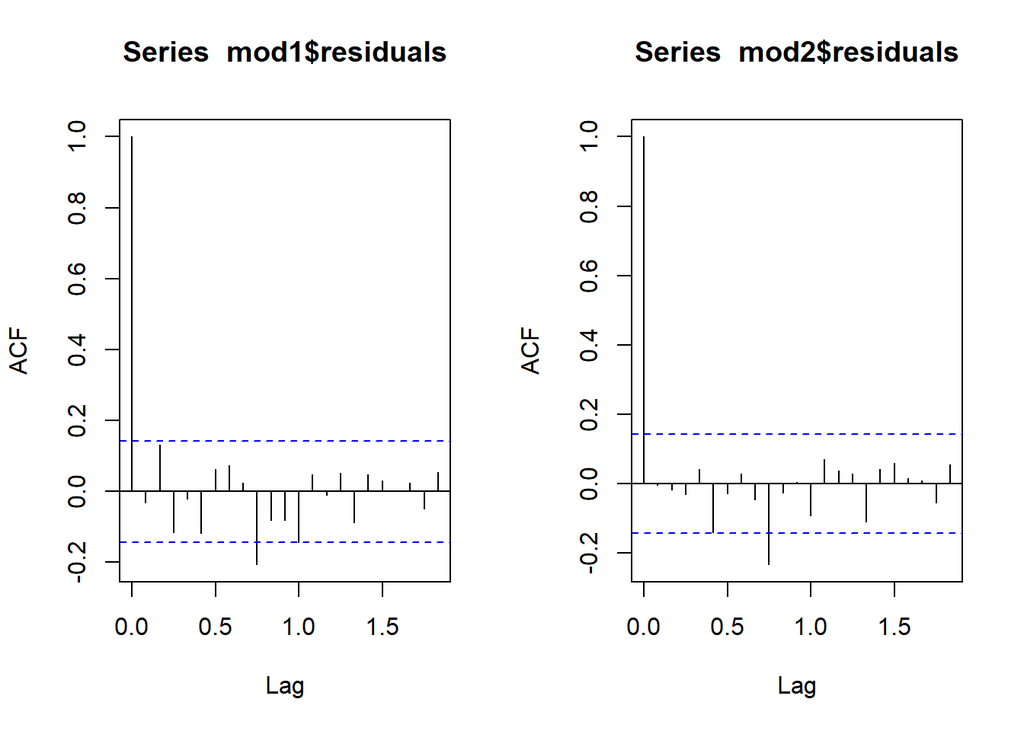

```r
par(mfrow=c(1,2))
acf(mod1$residuals)
acf(mod2$residuals)
```

On remarque bien la blancheur du residu pour les deux modeles choisient.

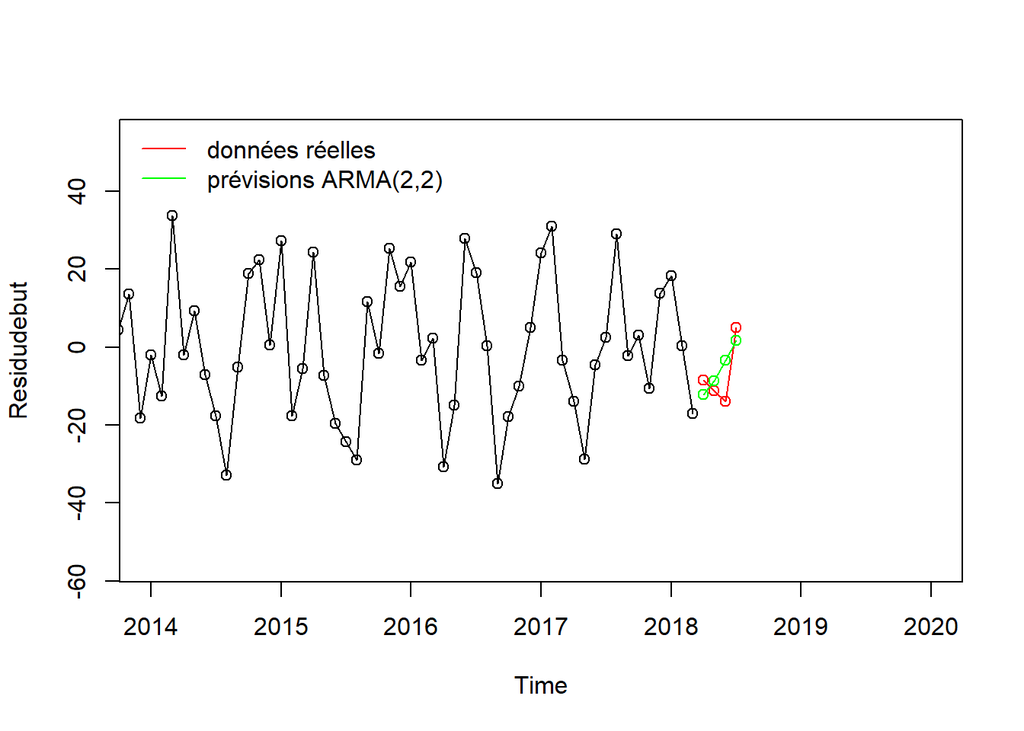

```r
pred=predict(mod1,n.ahead = 4)
plot.ts(Residudebut,,xlim=c(2014,2020),type='o')
lines(Residufin,col='red',type='o')
lines(pred$pred,col="green",type='o')
legend(x='topleft',legend=c('données réelles','prévisions ARMA(2,2)'),col=c('red','green'),lty=1,bty="n")
```

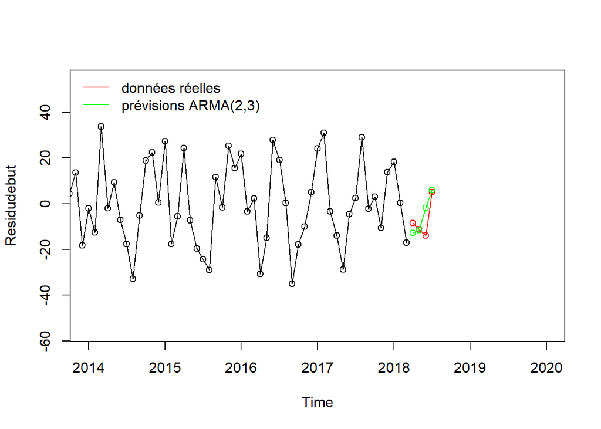

```r
pred=predict(mod2,n.ahead = 4)
plot.ts(Residudebut,,xlim=c(2014,2020),type='o')
lines(Residufin,col='red',type='o')
lines(pred$pred,col="green",type='o')
legend(x='topleft',legend=c('données réelles','prévisions ARMA(2,3)'),col=c('red','green'),lty=1,bty="n")
```

Le deuxieme modele ARMA(2,3) est le meillieur modele etant donne que c’est prevision se rapprochent plus des valeurs réelles que celui du modele ARMA(2,2)

**Retour à la serie initiale** En enlevant les 6 premieres valeur et 6 dernieres et en predisant les 4 valeurs on peut revenir à la serie initial en rajoutant la tendance et la saisonnalité .

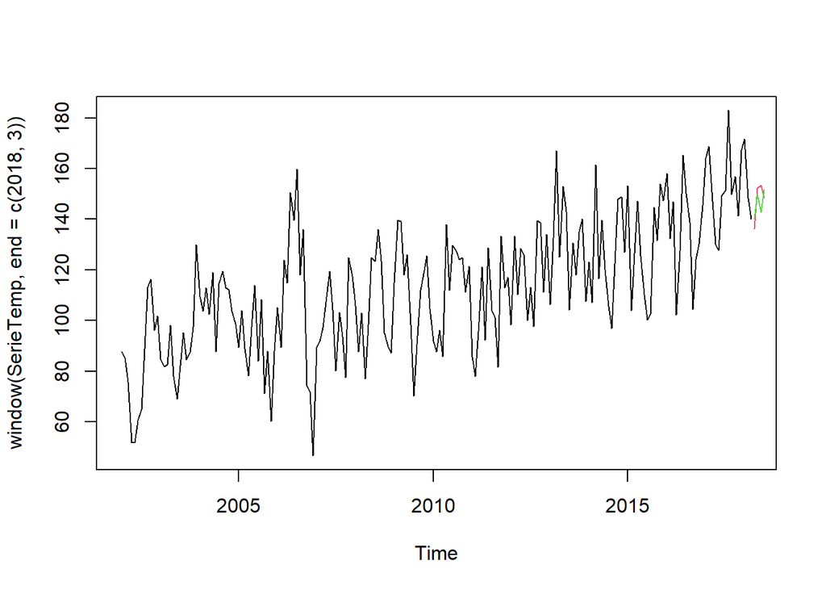

```r
pred=predict(mod1,n.ahead = 4)$pred+window(SerieTendance,start=c(2018,4),end=c(2018, 7))+window(Sh,start=c(2018,4),end=c(2018,7))

serietest = window(SerieTemp,start=c(2018,4),end=c(2018,7))
plot(window(SerieTemp, end = c(2018, 3)))
lines(pred, col = 2)
lines(serietest, col = 3)
```